# Random Forest Classification using Machine Learning for Stroke Prediction

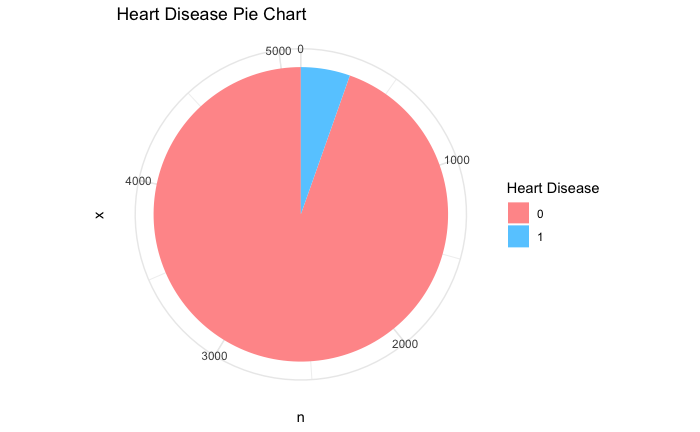

```r
# calculate frequency of heart disease values
heart_disease <- df_stroke %>%
  count(heart_disease)

# create pie chart
ggplot(heart_disease, aes(x = "", y = n, fill = factor(heart_disease)))+
  geom_bar(stat = "identity", width = 1)+
  coord_polar("y", start = 0)+
  theme_minimal()+
  labs(fill = "Heart Disease")+
  scale_fill_manual(values = c("#FF9999", "#66CCFF"))+
  ggtitle("Heart Disease Pie Chart")
```

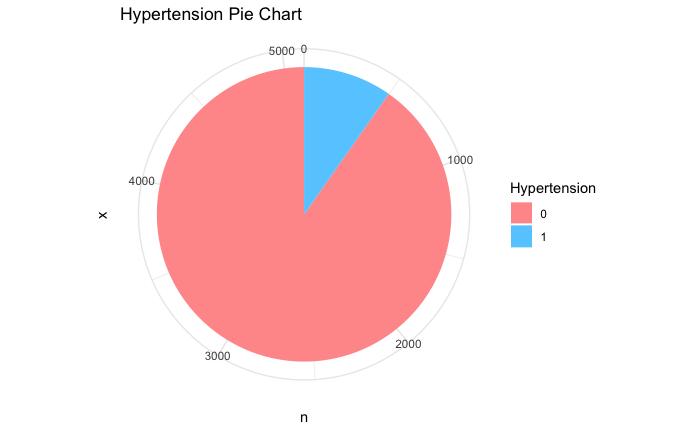

```r
hypertension <- df_stroke %>%
  count(hypertension)

ggplot(hypertension, aes(x = "", y = n, fill = factor(hypertension)))+
  geom_bar(stat = "identity", width = 1)+
  coord_polar("y", start = 0)+
  theme_minimal()+
  labs(fill = "Hypertension")+
  scale_fill_manual(values = c("#FF9999", "#66CCFF"))+
  ggtitle("Hypertension Pie Chart")
```

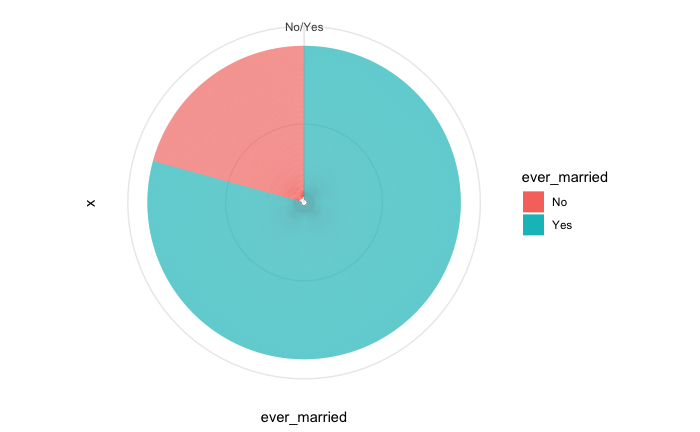

```r
ggplot(df_stroke, aes(x = "", y = ever_married, fill = ever_married)) +
  geom_bar(stat = "identity", width = 1) +
  coord_polar("y", start = 0) +
  theme_minimal()
```

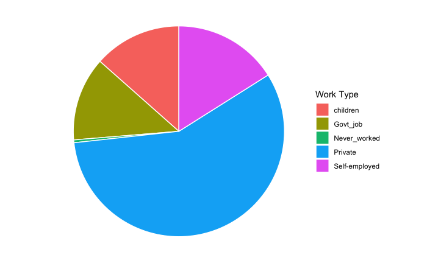

```r
ggplot(df_stroke, aes(x = "", fill = work_type)) +
  geom_bar(width = 1, color = "white") +
  coord_polar(theta = "y") +
  theme_void() +
  labs(fill = "Work Type")
```

Model Building and Prediction. Let’s split the final data set into training and test data set.

```r
n_obs<- nrow(df_stroke)
split<- round(n_obs * 0.7)
train<- df_stroke [1:split,]
```

Variable called n_obs and assigns it the value of the number of rows in the df_stroke dataset. ‘split’ assigns it the value of 70% of the total number of observations rounded to the nearest whole number. Last line creates a subset of the df_stroke dataset called train by selecting the rows from 1 to split.

Now we will create test datatset

```r
test<- df_stroke[(split +1): nrow(df_stroke),]
```

```r
dim(train)
```

```
[1] 3576   12
```

```r
dim(test)
```

```
[1] 1533   12
```

Above lines print the dimensions (number of rows and columns) of the train and test datasets.

```r
train$stroke <- as.factor(train$stroke)
test$stroke <- as.factor(test$stroke)
```

Above lines convert the stroke variable in both the train and test datasets to a categorical factor variable.

Modeling

We use Random Forest algorithm for this problem as it is normally used in supervised learning since our problem has only two possible outcomes.

```r
rf_model<-randomForest(formula= stroke~.,data = train)
rf_model
```

```
Call:
 randomForest(formula = stroke ~ ., data = train)
               Type of random forest: classification
                     Number of trees: 500
No. of variables tried at each split: 3

        OOB estimate of  error rate: 7.21%
Confusion matrix:
     0 1 class.error
0 3318 9  0.00270514
1  249 0  1.00000000
```

```r
levels(train$stroke)
```

```
[1] "0" "1"
```

```r
levels(test$stroke)
```

```
[1] "0"
```

Ensure that both datasets have the same levels for stroke factor variable.

```r
test$stroke <- factor(test$stroke, levels = levels(train$stroke))
```

Our Final Code to see how model is performing on the test dataset.

```r
confusionMatrix(predict(rf_model, test), test$stroke)
```

```
Confusion Matrix and Statistics

          Reference
Prediction    0    1
         0 1532    0
         1    1    0

               Accuracy : 0.9993
                 95% CI : (0.9964, 1)
    No Information Rate : 1
    P-Value [Acc > NIR] : 1

                  Kappa : 0

 Mcnemar's Test P-Value : 1

            Sensitivity : 0.9993
            Specificity :     NA
         Pos Pred Value :     NA
         Neg Pred Value :     NA
             Prevalence : 1.0000
         Detection Rate : 0.9993
   Detection Prevalence : 0.9993
      Balanced Accuracy :     NA

       'Positive' Class : 0
```

Conclusions:

The confusion matrix shows the performance of the random forest model on the test dataset. The rows correspond to the predicted classes (0 and 1) and the columns correspond to the actual classes.